# Excercise Activity Analysis

Karim M. Ibrahim

August 31, 2017

## Overview

In this document, the goal is to build a prediction model for the Weight Lifting Exercises Dataset. The Dataset contains a record of 6 particpants recording their motion when performing Unilateral Dumbbell Biceps Curl in five different positions.

## Exploratory data analysis

We start by loading the dataset and exploring its content. The official describtion of the dataset can be found on: http://web.archive.org/web/20161224072740/http:/groupware.les.inf.puc-rio.br/har. The dataset uses body sensors to record the motion of different body parts when performing the Bicebs curl excercise using dumbbells. The data contains different observations of participants performing the excercise. The data is labeled from “A” to “E” and each correspond to a different specification of performing the excercise.

We start by loading the required libraries and load the dataset.

```r
library(caret)
```

```r
library(corrplot)
library(mlbench)
```

```r
pml_training <- read.csv("~/Downloads/pml-training.csv",na.strings=c("","NA"))
head(pml_training)
```

The output is not shown because its to long. After looking into the data, we find certain columns with multible NA fields. We investigate the content of these columns to clean our data. We suspect that certain columns are corrupt, hence, we examine the number of NA values in each column.

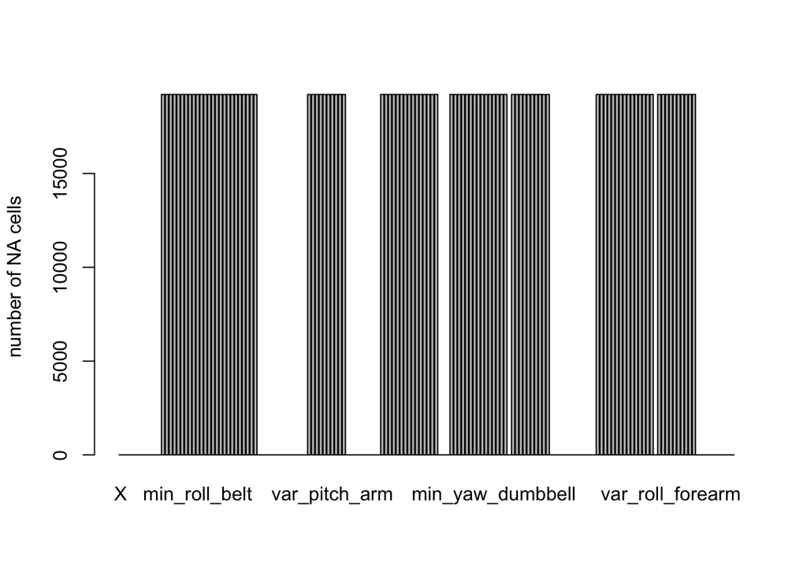

```r
NAperColumn <- apply(is.na(pml_training),2,sum)
barplot(NAperColumn,names.arg = names(pml_training),ylab = "number of NA cells")
```

We can observe a pattern here. Certain columns are mostly NA values in more than 19000 ovservations out of 19622. We proceed by removing these columns from our dataset.

```r
falseCols <- names(NAperColumn[NAperColumn>1000])
colNums <- which(names(pml_training) %in% falseCols)
clean_training <- pml_training[,-colNums]
```

Following, we remove columns that correspond to the particpants data. These columns are not helpful in training our model and do not contain useful information for training a classifier. We also extract the features and label into seperate variables.

```r
clean_training <- clean_training[,-seq(1:7)]
Features <- clean_training[,-length(clean_training)]
Labels <- clean_training[,length(clean_training)]
```

## Pre-processing the data

After cleaning the data from unuseful columns, we investigate the correlation between the features of the data, in case it is useful to perform a dimensionality reduction.

[figure not shown]

```r
Correlations <- cor(Features)
corrplot(Correlations, method="circle",tl.col="black", tl.srt=45,tl.cex = 0.4,order = "hclust")
```

```r
correlatedColumns <- findCorrelation(Correlations,cutoff = 0.8)
names(Features)[correlatedColumns]
```

```
##  [1] "accel_belt_z"     "roll_belt"        "accel_belt_y"
##  [4] "accel_dumbbell_z" "accel_belt_x"     "pitch_belt"
##  [7] "accel_arm_x"      "accel_dumbbell_x" "magnet_arm_y"
## [10] "gyros_dumbbell_x" "gyros_forearm_y"  "gyros_dumbbell_z"
## [13] "gyros_arm_x"
```

## Training the model

In the following we will train three models on dataset. We will use a 10-fold cross-validation to estimate the performance of our models.

```r
train_control <- trainControl(method="cv", number=10,preProcOptions = "pca", allowParallel=TRUE)
```

The models we are investigating are: Random Forest, SVM with radial kernel and a neural network.

```r
rfModel <- train(Features,Labels,method = "rf",trControl=train_control)
svmModel <- train(Features,Labels,method = "svmRadial",trControl=train_control)
nnModel <- train(Features,Labels,method = "nnet",trControl=train_control)
print(rfModel)
```

```
## Random Forest
##
## 19622 samples
##    52 predictor
##     5 classes: 'A', 'B', 'C', 'D', 'E'
##
## No pre-processing
## Resampling: Cross-Validated (10 fold)
## Summary of sample sizes: 17662, 17661, 17660, 17659, 17658, 17659, ...
## Resampling results across tuning parameters:
##
##   mtry  Accuracy   Kappa
##    2    0.9950055  0.9936817
##   27    0.9949550  0.9936181
##   52    0.9901650  0.9875581
##
## Accuracy was used to select the optimal model using  the largest value.
## The final value used for the model was mtry = 2.
```

```r
print(svmModel)
```

```
## Support Vector Machines with Radial Basis Function Kernel
##
## 19622 samples
##    52 predictor
##     5 classes: 'A', 'B', 'C', 'D', 'E'
##
## No pre-processing
## Resampling: Cross-Validated (10 fold)
## Summary of sample sizes: 17660, 17660, 17661, 17660, 17661, 17660, ...
## Resampling results across tuning parameters:
##
##   C     Accuracy   Kappa
##   0.25  0.8821737  0.8505972
##   0.50  0.9108654  0.8870007
##   1.00  0.9370096  0.9201703
##
## Tuning parameter 'sigma' was held constant at a value of 0.01408043
## Accuracy was used to select the optimal model using  the largest value.
## The final values used for the model were sigma = 0.01408043 and C = 1.
```

```r
print(nnModel)
```

```
## Neural Network
##
## 19622 samples
##    52 predictor
##     5 classes: 'A', 'B', 'C', 'D', 'E'
##
## No pre-processing
## Resampling: Cross-Validated (10 fold)
## Summary of sample sizes: 17659, 17660, 17660, 17659, 17659, 17660, ...
## Resampling results across tuning parameters:
##
##   size  decay  Accuracy   Kappa
##   1     0e+00  0.3218285  0.09077228
##   1     1e-04  0.3220931  0.08579313
##   1     1e-01  0.3404407  0.12277841
##   3     0e+00  0.3850745  0.20705911
##   3     1e-04  0.3655558  0.17725873
##   3     1e-01  0.3828900  0.22146461
##   5     0e+00  0.4438443  0.29583648
##   5     1e-04  0.4173885  0.26578792
##   5     1e-01  0.4219745  0.25740748
##
## Accuracy was used to select the optimal model using  the largest value.
## The final values used for the model were size = 5 and decay = 0.
```

We find training accuracy is 99% for the random forest which is the best model out of the 3 proposed models.